# The Price of Risk as Driver of Business Cycles

Brown Economics Faculty Summer Seminar

Tobias Adrian

International Monetary Fund<sup>1</sup>

Matthew DeHaven

Brown University

Fernando Duarte

Brown University

July 3, 2024

<sup>1</sup>The views expressed here are the authors’ and are not necessarily representative of the views of the International Monetary Fund, its Management, or its Executive Directors.

## Definitions

- The *market price of risk* is the equilibrium compensation required by investors to hold all aggregate risk
  - If all risk were tradable in the stock market,
    $$\text{market price of risk} =
    \frac{
    \text{expected stock returns} - \text{risk-free rate}
    }{
    \text{volatility of stock returns}
    }$$
- The *business cycle* is the comovement among macroeconomic variables over the 1 to 10 year “short run”
  - Patterns of comovement are qualitatively the same across different cycles

## Main Result: Price of Risk “drives” Business Cycles

- Empirically, two new patterns
  1. Price of risk shocks essentially the same as “business cycle shock”
  2. For business cycle variables $y_t$,

  $$\mathbb{E}[y_{t+1} \mid \text{price of risk}_t] =
  a + b Vol[y_{t+1} \mid \text{price of risk}_t]$$
- Theoretically,
  - Empirical patterns inconsistent with mainstream models
  - But consistent with a model of financial frictions

## Price of Risk and Business Cycle Shocks Match Up

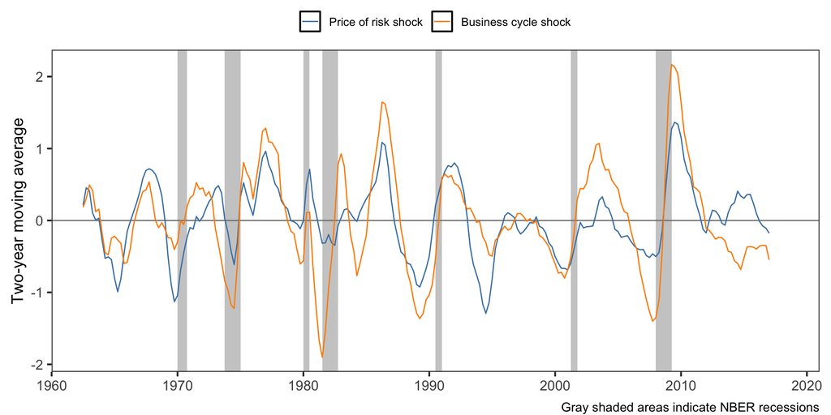

## Impulse Response Functions Also Coincide

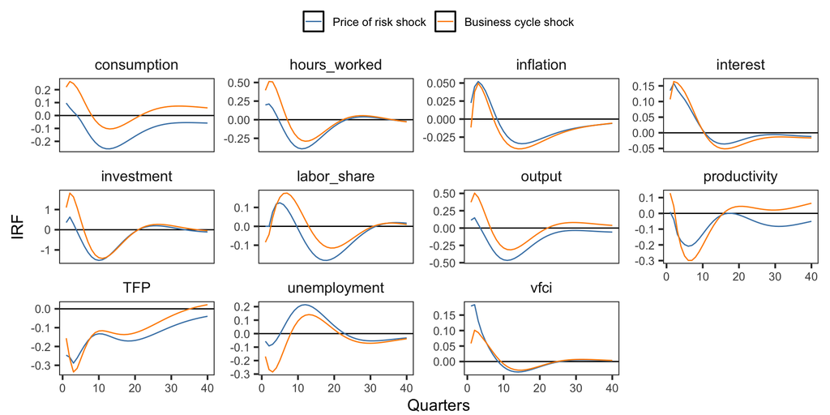

## Linear Relation for Conditional Means and Volatilities

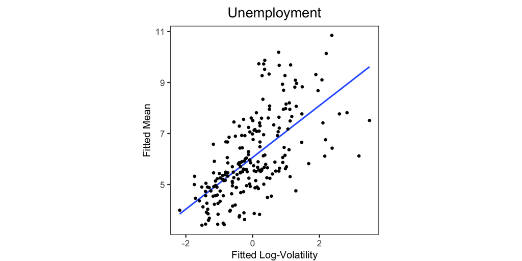

## Business cycles

### Causes

- Empirically, just one shock captures 50-75% of variation of many variables
- In models, usually a single big shock: TFP, beliefs, confidence, etc.
- Common propagation can look like a single shock

### Why we care

- Causes determine whether fluctuations are inefficient
- Crucial for welfare and policy

## Empirical Framework: Vector Autoregression (VAR)

Structural VAR($p$) with $k$ variables in vector $y_t$,
$$B_0 y_t = B_1 y_{t-1} + . . . + B_p y_{t-p} + w_t$$
where structural shocks $w_t$ are white noise

Estimate reduced-form coefficients $A_i$ and residuals $u_t$
$$y_t = \underbrace{B_0^{-1}B_1}_{A_1} y_{t-1} + \dots + \underbrace{B_0^{-1}B_p}_{A_p} y_{t-p} + \underbrace{B_0^{-1}w_t}_{u_t}$$

## VAR Specification is Standard

- 1962 Q1 to 2017 Q1 with $p=2$ lags
- $k=10$ macro variables: unemployment, interest, inflation, output, investment, consumption, hours worked, labor share, TFP, productivity
- Or, $k=11$ with price of risk
  - Use “volatility financial conditions index”

## Volatility Financial Conditions Index (VFCI)

- VFCI is the volatility of consumption spanned by financial assets
- VFCI is a linear combination of stock returns, Treasury term and liquidity spreads, corporate credit and default spreads
- Measures price of risk of representative agent in large class of models
- Can be interpreted as tightness in financial conditions

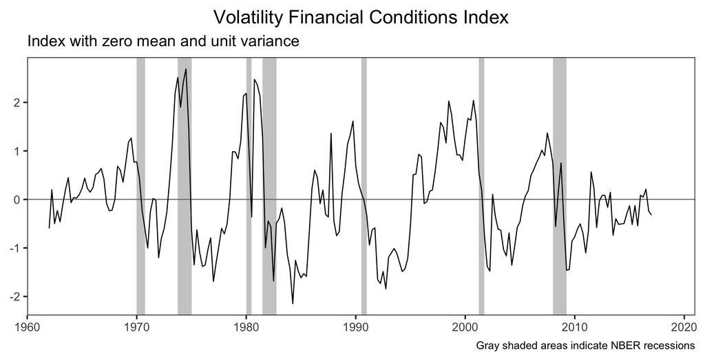

## Usual Identification Problem

- Compare VAR in structural and reduced form
  $$\begin{align*}
  B_0 y_t &= B_1 y_{t-1} + . . . + B_p y_{t-p} + w_t \\
  y_t &= \underbrace{B_0^{-1}B_1}_{A_1} y_{t-1} + \dots + \underbrace{B_0^{-1}B_p}_{A_p} y_{t-p} + \underbrace{B_0^{-1}w_t}_{u_t}
  \end{align*}$$
- Structural shocks $w_t$ related to reduced-form residuals $u_t$ by
  $$w_t = B_0 u_t$$
  but $B_0$ not identified

## A Main Business Cycle Shock

- Identify a “main business-cycle” shock $w_t^{(\text{MBC})}$ as in Angeletos, Collard, and Dellas (2020)
  1. Pick a target variable (e.g., unemployment)
  2. Find linear combination of residuals
     $$w_t^{(\text{MBC})} = b^T u_t$$
     that maximizes contribution of MBC shock to the volatility of target variable over business-cycle frequencies

## Same Business Cycle Shock for Different Targets

- MBC shock explains 50-75% of volatility of unemployment, investment, output, hours worked
- Targeting unemployment, output, hours worked, consumption, or investment identifies same shock
- Shock looks like demand shock without inflation
- Angeletos, Collard, and Dellas (2020) propose a “confidence” shock (higher-order belief shocks) as explanation

## Estimation of Volatility of Consumption

- Assume conditional volatility of consumption residuals is linear in VAR variables
- Two-step estimation
  - Estimate VAR and define $\sigma_t := \hat{u}_t^{(\text{cons})}$
  - Run OLS regression
    $$\log \sigma_t^2 = c^T y_t + \vartheta_t$$
- Use $\hat{c}^T y_t$

## IRF of Max-Share Price of Risk Shock

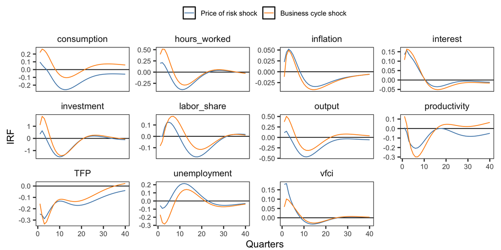

## IRF of Timing Price of Risk Shock

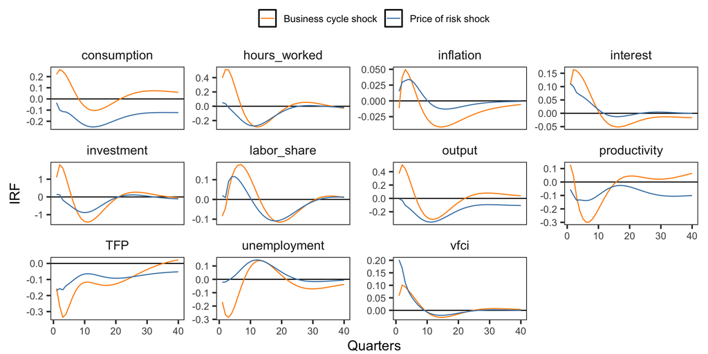

## IRF of Heteroskedasticity Price of Risk Shock

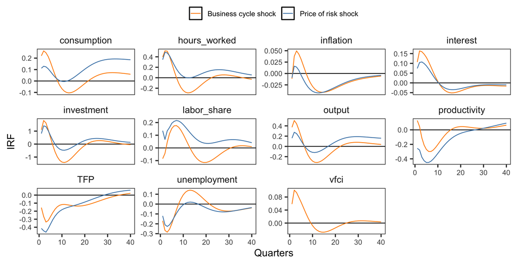

## Mean and Vol Linked by Price of Risk

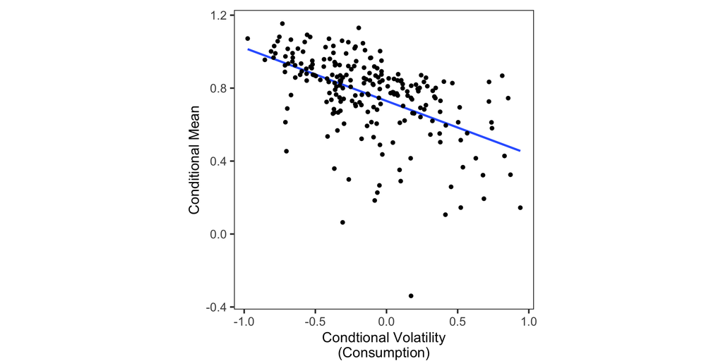

## Mean and Vol Linked by Price of Risk

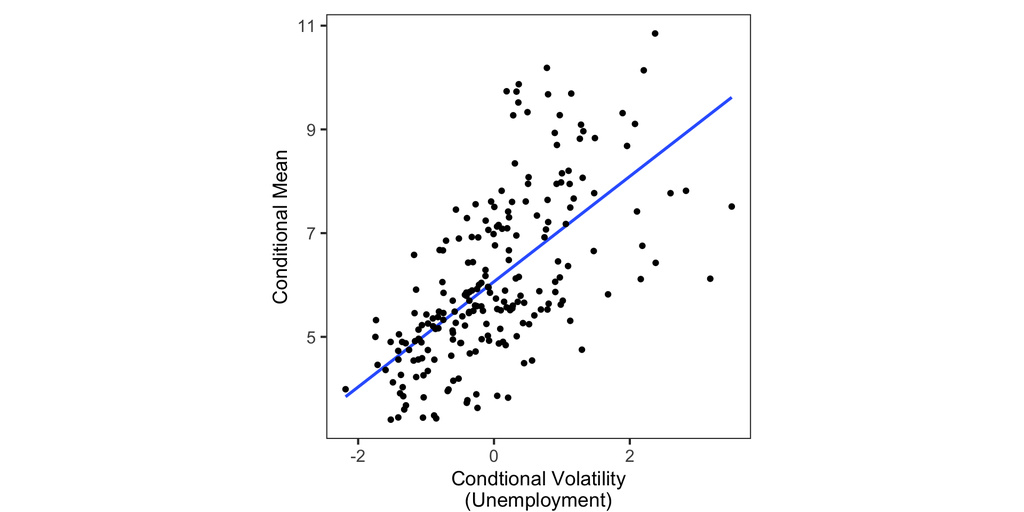

## Conclusion

### A New Business Cycle Fact

We show a new feature of business cycles

- the price of risk comoves with the mean and vol of macro varaibles during the cycle
- not consistent with real business cycle (RBC) or New Keynesian models

## Conclusion

### Financial Conditions Propagate the Business Cycle

There exists a general equilibrium structural model that is consistent with

- the price of risk comoving with the business cycle
- the empirical mean-vol relationship of macro variables

In the model, financial sector aggregates, amplifies, and propagates disparate shocks

- Driven by a financial friction: the value-at-risk constraint
- Not a single shock but a story of strong propagation

# Appendix

## References

Angeletos, George-Marios, Fabrice Collard, and Harris Dellas. 2020. “Business-Cycle Anatomy.” *American Economic Review* 110 (10): 3030–70. https://doi.org/10.1257/aer.20181174.